# Machine Learning Project

Jaime Hernandez

August 31, 2019

Background

Using devices such as Jawbone Up, Nike FuelBand, and Fitbit it is now possible to collect a large amount of data about personal activity relatively inexpensively. These type of devices are part of the quantified self movement - a group of enthusiasts who take measurements about themselves regularly to improve their health, to find patterns in their behavior, or because they are tech geeks. One thing that people regularly do is quantify how much of a particular activity they do, but they rarely quantify how well they do it. In this project, your goal will be to use data from accelerometers on the belt, forearm, arm, and dumbell of 6 participants. They were asked to perform barbell lifts correctly and incorrectly in 5 different ways. More information is available from the website here: http://groupware.les.inf.puc-rio.br/har (see the section on the Weight Lifting Exercise Dataset).

Data

The training data for this project are available here: [https://d396qusza40orc.cloudfront.net/predmachlearn/pml-training.csv]

The test data are available here: [https://d396qusza40orc.cloudfront.net/predmachlearn/pml-testing.csv]

The data for this project come from this source: [http://groupware.les.inf.puc-rio.br/har]. If you use the document you create for this class for any purpose please cite them as they have been very generous in allowing their data to be used for this kind of assignment.

What you should submit

The goal of your project is to predict the manner in which they did the exercise. This is the “classe” variable in the training set. You may use any of the other variables to predict with. You should create a report describing how you built your model, how you used cross validation, what you think the expected out of sample error is, and why you made the choices you did. You will also use your prediction model to predict 20 different test cases.

Your submission should consist of a link to a Github repo with your R markdown and compiled HTML file describing your analysis. Please constrain the text of the writeup to < 2000 words and the number of figures to be less than 5. It will make it easier for the graders if you submit a repo with a gh-pages branch so the HTML page can be viewed online (and you always want to make it easy on graders :-). You should also apply your machine learning algorithm to the 20 test cases available in the test data above. Please submit your predictions in appropriate format to the programming assignment for automated grading. See the programming assignment for additional details.

Write up

Reproducibility:

In order to make this project reproducible, the seed: 555 was used to generate all random numbers in the project. Libraries needed to generate the outputs of this report are included in the “Data Processing, cleansing, and sub setting” section of the code.

Model Building Process:

In order to predict the type of exercise being performed with the available data, a feature building-like process was followed to remove highly correlated variables. Once the desired features were selected, two different machine learning classification models were built and evaluated. The model with the highest accuracy was selected. The five possible outcomes were present in the data: - exactly according to the specification (Class A) - throwing the elbows to the front (Class B) - lifting the dumbbell only halfway (Class C) - lowering the dumbbell only halfway (Class D) - throwing the hips to the front (Class E)

Cross-validation and robustness:

As mentioned in the data section, two datasets were provided for this project. The training set was used for model building, and the testing set was used to ultimately evaluate the models. To make the models more robust and have a better estimate of standard errors, the training set was split into two subsets (75% and 25%); the larger subset was used to create the models which were then tested on the smaller training subset followed by the official test on the testing set.

Expected out-of-sample error:

The expected out-of-sample error will correspond to the accuracy calculation measured by the number of time the models were right on the validation subset of the training set, over the number of rows in the validation training subset.

Justifying modeling choices:

1. Given that the dataset contained 160 total variables, a covariance analysis was performed to eliminate highly correlated variables. This would remove variance and lessen the possibility of overfitting; greater than |0.9| was selected as the threshold. Variables that were constant were removed for the same reason. (Other variables such as username and timestamp were removed as business intuition can be used to discard them as unnecessary).
2. The training data was broken up into 2 subsets to allow for cross validation as described in the model building process section
3. A random forest and a boosting model with trees models were selected for this tasks as they are known for their applicability in classification.

Code and Results:

1. Data processing, cleansing, and sub setting:

```r
#Loaad packages
library(dplyr)
library(caret)
library(randomForest)
library(e1071)
library(gbm)
#set seed

set.seed(555)

##Read training and testing data

train_data <- read.csv("pml-training.csv", stringsAsFactors = FALSE, na.strings=c("NA","#DIV/0!", ""))
train_data[is.na(train_data)] <- 0

test_data <- read.csv("pml-testing.csv", stringsAsFactors = FALSE, na.strings=c("NA","#DIV/0!", ""))
test_data[is.na(test_data)] <- 0


head(train_data)
```

[output not shown]

[output cut: 265 more lines]

```r
#Remove variables that will no add any value to model

train_data <- train_data %>% select(8:dim(train_data)[2])

# Create subset of data from train data with cross validation in mind

subsamples <- createDataPartition(y=train_data$classe, p=0.75, list=FALSE)
subTraining <- train_data[subsamples, ]
subTesting <- train_data[-subsamples, ]

#Split variables that can be measured by covariance
char_cols <- subTraining[,sapply(subTraining, is.character)]
numeric_cols <- subTraining[,sapply(subTraining, is.numeric)]
```

2. Reduce the number of variables to minimize variance:

```r
#Remove variables that are always constant
const_cols <- which(apply(numeric_cols, 2, var)==0)

numeric_cols <- numeric_cols %>%
    select(-const_cols)

#remove highly correlated variables
tmp <- cor(numeric_cols)
tmp[upper.tri(tmp)] <- 0
diag(tmp) <- 0

#set 90% as the threshold
sub_train_final <- numeric_cols[, apply(tmp,2,function(x) all(abs(x) <= 0.9))]

sub_train_final <- cbind(sub_train_final, classe = char_cols)
```

3. Random forest model:

```r
#Remove variables that are always constant

model_1 <- randomForest(classe ~. , data=sub_train_final, method="class")
summary(model_1)
```

```
##                 Length Class  Mode
## call                4  -none- call
## type                1  -none- character
## predicted       14718  factor numeric
## err.rate         3000  -none- numeric
## confusion          30  -none- numeric
## votes           73590  matrix numeric
## oob.times       14718  -none- numeric
## classes             5  -none- character
## importance        111  -none- numeric
## importanceSD        0  -none- NULL
## localImportance     0  -none- NULL
## proximity           0  -none- NULL
## ntree               1  -none- numeric
## mtry                1  -none- numeric
## forest             14  -none- list
## y               14718  factor numeric
## test                0  -none- NULL
## inbag               0  -none- NULL
## terms               3  terms  call
```

```r
# Predicting:
prediction_1 <- predict(model_1, subTesting, type = "class")

# Test results on subTesting data set:
confusionMatrix(as.factor(prediction_1), as.factor(subTesting$classe))
```

```
## Confusion Matrix and Statistics
##
##           Reference
## Prediction    A    B    C    D    E
##          A 1394    8    0    0    0
##          B    0  936    4    0    0
##          C    0    5  850   11    0
##          D    0    0    1  793    0
##          E    1    0    0    0  901
##
## Overall Statistics
##
##                Accuracy : 0.9939
##                  95% CI : (0.9913, 0.9959)
##     No Information Rate : 0.2845
##     P-Value [Acc > NIR] : < 2.2e-16
##
##                   Kappa : 0.9923
##
##  Mcnemar's Test P-Value : NA
##
## Statistics by Class:
##
##                      Class: A Class: B Class: C Class: D Class: E
## Sensitivity            0.9993   0.9863   0.9942   0.9863   1.0000
## Specificity            0.9977   0.9990   0.9960   0.9998   0.9998
## Pos Pred Value         0.9943   0.9957   0.9815   0.9987   0.9989
## Neg Pred Value         0.9997   0.9967   0.9988   0.9973   1.0000
## Prevalence             0.2845   0.1935   0.1743   0.1639   0.1837
## Detection Rate         0.2843   0.1909   0.1733   0.1617   0.1837
## Detection Prevalence   0.2859   0.1917   0.1766   0.1619   0.1839
## Balanced Accuracy      0.9985   0.9926   0.9951   0.9930   0.9999
```

4. Boosting with trees model:

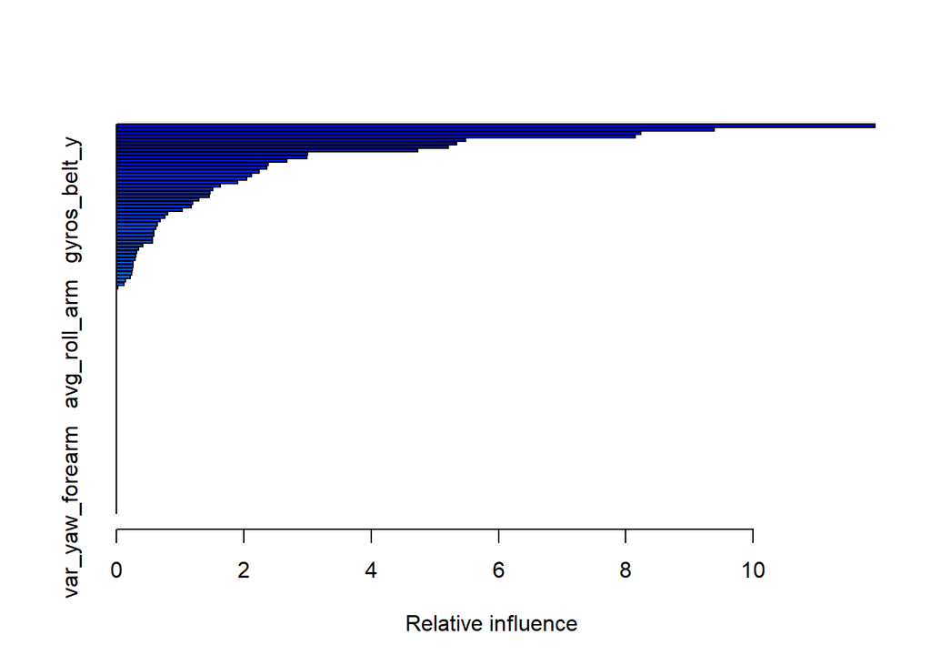

```
##                                             var      rel.inf
## yaw_belt                               yaw_belt 11.909356595
## pitch_forearm                     pitch_forearm  9.389210806
## accel_belt_z                       accel_belt_z  8.237224243
## magnet_dumbbell_z             magnet_dumbbell_z  8.143399727
## magnet_belt_z                     magnet_belt_z  5.481074613
## magnet_dumbbell_y             magnet_dumbbell_y  5.337438350
## roll_forearm                       roll_forearm  5.211943197
## gyros_belt_z                       gyros_belt_z  4.731941731
## accel_forearm_x                 accel_forearm_x  3.002592571
## roll_dumbbell                     roll_dumbbell  2.991717530
## magnet_belt_y                     magnet_belt_y  2.680938072
## magnet_forearm_z               magnet_forearm_z  2.386800551
## accel_dumbbell_y               accel_dumbbell_y  2.357464496
## magnet_dumbbell_x             magnet_dumbbell_x  2.244087605
## yaw_arm                                 yaw_arm  2.125887525
## gyros_dumbbell_y               gyros_dumbbell_y  2.047863465
## roll_arm                               roll_arm  1.902769170
## magnet_arm_z                       magnet_arm_z  1.632320503
## accel_dumbbell_z               accel_dumbbell_z  1.514239025
## accel_forearm_z                 accel_forearm_z  1.466904072
## accel_dumbbell_x               accel_dumbbell_x  1.461041623
## gyros_belt_y                       gyros_belt_y  1.290810767
## gyros_arm_y                         gyros_arm_y  1.200968982
## magnet_arm_y                       magnet_arm_y  1.178025166
## magnet_belt_x                     magnet_belt_x  1.032406235
## magnet_forearm_y               magnet_forearm_y  0.802529274
## magnet_forearm_x               magnet_forearm_x  0.761262032
## gyros_belt_x                       gyros_belt_x  0.686422949
## total_accel_dumbbell       total_accel_dumbbell  0.647989967
## gyros_dumbbell_x               gyros_dumbbell_x  0.622707288
## total_accel_forearm         total_accel_forearm  0.590833806
## magnet_arm_x                       magnet_arm_x  0.585172031
## accel_forearm_y                 accel_forearm_y  0.571969751
## accel_arm_x                         accel_arm_x  0.563905491
## accel_belt_x                       accel_belt_x  0.409229281
## gyros_forearm_z                 gyros_forearm_z  0.347276039
## gyros_dumbbell_z               gyros_dumbbell_z  0.319370394
## pitch_dumbbell                   pitch_dumbbell  0.310588738
## total_accel_arm                 total_accel_arm  0.299775495
```

[output cut: 57 more lines]

```
## stddev_yaw_dumbbell         stddev_yaw_dumbbell  0.000000000
## var_yaw_dumbbell               var_yaw_dumbbell  0.000000000
## kurtosis_picth_forearm   kurtosis_picth_forearm  0.000000000
## skewness_roll_forearm     skewness_roll_forearm  0.000000000
## skewness_pitch_forearm   skewness_pitch_forearm  0.000000000
## max_roll_forearm               max_roll_forearm  0.000000000
## max_picth_forearm             max_picth_forearm  0.000000000
## min_pitch_forearm             min_pitch_forearm  0.000000000
## min_yaw_forearm                 min_yaw_forearm  0.000000000
## var_accel_forearm             var_accel_forearm  0.000000000
## avg_roll_forearm               avg_roll_forearm  0.000000000
## var_roll_forearm               var_roll_forearm  0.000000000
## avg_pitch_forearm             avg_pitch_forearm  0.000000000
## avg_yaw_forearm                 avg_yaw_forearm  0.000000000
## var_yaw_forearm                 var_yaw_forearm  0.000000000
```

```r
#Remove variables that are always constant

model_2 <- train(classe ~. ,method = "gbm", data=sub_train_final, verbose = FALSE)

#Analyze mddel
summary(model_2)
```

```r
# Predicting:
#1000 trees selected to leverage the robustness of the model
prediction_2 <- predict(model_2, subTesting, n.trees = 1000)

# Test results on subTesting data set:
confusionMatrix(as.factor(prediction_2), as.factor(subTesting$classe))
```

```
## Confusion Matrix and Statistics
##
##           Reference
## Prediction    A    B    C    D    E
##          A 1367   42    0    1    3
##          B   20  872   37   11    4
##          C    8   26  804   27    9
##          D    0    5   13  761    8
##          E    0    4    1    4  877
##
## Overall Statistics
##
##                Accuracy : 0.9545
##                  95% CI : (0.9483, 0.9602)
##     No Information Rate : 0.2845
##     P-Value [Acc > NIR] : < 2.2e-16
##
##                   Kappa : 0.9425
##
##  Mcnemar's Test P-Value : 6.608e-05
##
## Statistics by Class:
##
##                      Class: A Class: B Class: C Class: D Class: E
## Sensitivity            0.9799   0.9189   0.9404   0.9465   0.9734
## Specificity            0.9869   0.9818   0.9827   0.9937   0.9978
## Pos Pred Value         0.9674   0.9237   0.9199   0.9670   0.9898
## Neg Pred Value         0.9920   0.9806   0.9873   0.9896   0.9940
## Prevalence             0.2845   0.1935   0.1743   0.1639   0.1837
## Detection Rate         0.2788   0.1778   0.1639   0.1552   0.1788
## Detection Prevalence   0.2881   0.1925   0.1782   0.1605   0.1807
## Balanced Accuracy      0.9834   0.9503   0.9615   0.9701   0.9856
```

6. Submission:

```r
prediction_final <- predict(model_1, test_data, type = "class")
prediction_final
```

```
##  1  2  3  4  5  6  7  8  9 10 11 12 13 14 15 16 17 18 19 20
##  B  A  B  A  A  E  D  B  A  A  B  C  B  A  E  E  A  B  B  B
## Levels: A B C D E
```